# Sensitivity analysis — the 8-class solution vs the retained 4-class model

Leadership LCA (FONDECYT 1170239): enumeration-uncertainty robustness check

Author

Andres Gonzalez Santa Cruz

Published

July 1, 2026

# Why this notebook

The main analysis retains **4 latent leadership profiles** on grounds of parsimony, entropy and interpretability. However, in the class-enumeration table (Table 1 of the main file, refit with 4,000 random starts on the **13 items** — item 3 excluded) the **BIC is minimised at 8 classes and the CAIC at 7** (while AIC and SABIC keep decreasing), so the larger, information-criterion-preferred solution lies around 7–8 classes. We examine the **8-class** solution here because it is the **global BIC minimum** (BIC = 43122.3 at 8, vs 43142.1 at 7 and 43154.3 at 9).

This notebook is an **enumeration-uncertainty sensitivity analysis**: it re-estimates the *same* measurement model with `nclass = 8`, characterises those 8 profiles, shows **how they map onto the retained 4 classes**, and checks whether the **covariate associations replicate**. It is complementary to — not a replacement for — the naive-vs-BCH classification-error sensitivity (Table S3 of the main file).

> Same data, same 13 items (item 3 excluded), same concomitant (`~ sex_woman`), same seed (2125) as the main analysis, so the 4-class results here reproduce the main file exactly.

```r
suppressMessages({
  library(glca); library(haven); library(dplyr); library(tidyr); library(tibble)
  library(purrr); library(ggplot2); library(scales); library(knitr); library(kableExtra)
})
set.seed(2125); options(scipen = 999)
## Random starting values for every glca() fit below (local-maxima safeguard).
## Lower to ~50 for quick drafts; keep 4000 for the final run. Same lucky seed.
n_init <- 4000
```

```r
## ---- file path (same resolver as the main analysis) --------------------
resolve_drive_path <- function(rel,
    roots = c("H:/My Drive", "G:/Mi unidad", "C:/Users/andre/Google Drive")) {
  rel <- gsub("\\\\", "/", rel)
  for (r in roots) { p <- file.path(r, rel); if (file.exists(p)) return(p) }
  stop("No se encontro el archivo en ninguna raiz conocida.")
}
raw_path <- resolve_drive_path(
  "DOCUMENTOS/6.TESIS 2018/LCA NAQ/BD_2020_input3_match_not_miss.rds")
raw <- readRDS(raw_path); names(raw) <- janitor::make_clean_names(names(raw))

## item 3 (lid_des3) is EXCLUDED from the LCA, exactly as in the main analysis,
## so 13 items enter every fit here (lid_des1..14 without lid_des3).
items <- paste0("lid_des", c(1:2, 4:14))
d <- raw
## items: shift 0-3 -> 1-4 if needed, as in the main file
item_min <- suppressWarnings(min(vapply(items,
  function(it) min(as.numeric(d[[it]]), na.rm = TRUE), numeric(1))))
shift <- if (is.finite(item_min) && item_min == 0) 1L else 0L
for (it in items) d[[it]] <- factor(as.numeric(d[[it]]) + shift, levels = 1:4)

## covariate cleaning (same mapping / yes-levels as the main file)
vars <- list(eri = "desbalance_dic", auditc_hazard = "auditc", no_union = "org_sind",
             naq_frequent = "naq_a", bully_self = "autonaq", sex_harass = "acos_sex",
             sex_woman = "a52")
yes_levels <- list(sex_woman = "Women", eri = "Yes", naq_frequent = "2",
                   bully_self = "Yes", sex_harass = "2", auditc_hazard = "Yes",
                   no_union = "Yes")
as_num <- function(x) {
  if (is.factor(x)) {
    suppressWarnings(as.numeric(as.character(x)))
  } else {
    as.numeric(haven::zap_labels(x))
  }
}
to01 <- function(x, yes) {
  f <- as.character(haven::as_factor(x)); f[f %in% c("NA","Not Apply","NaN","")] <- NA
  out <- as.integer(f %in% yes); out[is.na(f)] <- NA_integer_; out
}
for (nm in names(yes_levels)) d[[nm]] <- to01(d[[vars[[nm]]]], yes_levels[[nm]])
d$age <- as_num(d[["a53"]]); d$job_sat <- as_num(d[["satis"]])
d$.w <- if ("weight" %in% names(d)) as_num(d[["weight"]]) else 1

## complete on the 14 items AND the concomitant (keeps post/modal aligned)
d_lca <- d[stats::complete.cases(d[, c(items, "sex_woman")]), ]
cat("Analysis n:", nrow(d_lca), "\n")
```

```
Analysis n: 1847
```

```r
relative_entropy <- function(post) {
  post <- as.matrix(post); n <- nrow(post); K <- ncol(post)
  1 - (-sum(post * log(pmax(post, 1e-12)))) / (n * log(K))
}
get_post <- function(g) { p <- g$posterior; if (is.list(p)) p <- p[[1]]; as.matrix(p) }
get_rho  <- function(g) { r <- g$param$rho; if (is.list(r) && is.list(r[[1]])) r <- r[[1]]; r }

## classification matrix D[t,w] = P(W=w | X=t)  (full sample, fixed)
class_matrix <- function(post, modal) {
  K <- ncol(post); ind <- outer(modal, 1:K, `==`) * 1
  A <- t(as.matrix(post)) %*% ind; A / rowSums(A)
}
## ML three-step for one covariate z, reference class = `ref` (Vermunt 2010).
ml3step <- function(z, post, modal, sw = NULL, ref = 1L, D = NULL) {
  post <- as.matrix(post); K <- ncol(post)
  if (is.null(sw)) sw <- rep(1, nrow(post))
  if (is.null(D)) D <- class_matrix(post, modal)     # fixed D on FULL sample
  ## reorder so `ref` is the first (baseline) category
  ord <- c(ref, setdiff(seq_len(K), ref))
  D <- D[ord, ord]; modal <- match(modal, ord)
  z <- as.numeric(z); ok <- !is.na(z)
  z <- z[ok]; modal <- modal[ok]; sw <- sw[ok]; n <- length(z)
  Dw <- t(D[, modal])
  negll <- function(par) {
    a <- c(0, par[seq(1, 2*(K-1), 2)]); b <- c(0, par[seq(2, 2*(K-1), 2)])
    eta <- outer(rep(1, n), a) + outer(z, b); eta <- eta - apply(eta, 1, max)
    pis <- exp(eta); pis <- pis / rowSums(pis)
    -sum(sw * log(pmax(rowSums(pis * Dw), 1e-12)))
  }
  fit <- optim(rep(0, 2*(K-1)), negll, method = "BFGS", hessian = TRUE)
  V <- tryCatch(solve(fit$hessian), error = function(e) matrix(NA, length(fit$par), length(fit$par)))
  bi <- seq(2, 2*(K-1), 2); b <- fit$par[bi]; se <- sqrt(diag(V))[bi]
  tibble::tibble(class_ord = 2:K, orig_class = ord[-1],
                 OR = exp(b), lo = exp(b - 1.96*se), hi = exp(b + 1.96*se))
}
```

# Fit the 4- and 8-class models

```r
item_f <- as.formula(paste0("item(", paste(items, collapse = ", "), ") ~ sex_woman"))
Kbig <- 8                      # the larger, IC-preferred solution (global BIC minimum, 13 items)

## Robust fit: with n.init = 4000, a single degenerate random start would make
## glca error (loglik -> NaN -> maxdiff -> NA). These fits run in the MAIN process
## under the default Mersenne-Twister RNG (no furrr here, so the L'Ecuyer-CMRG
## issue of the main enumeration does not arise), but we still retry on the next
## seed as a safeguard. 2125 (lucky seed) is used whenever it works.
fit_glca <- function(K) {
  for (s in 2125:2134) {
    g <- tryCatch(glca(item_f, data = d_lca, nclass = K, seed = s,
                       n.init = n_init, verbose = FALSE),
                  error = function(e) NULL)
    if (!is.null(g)) return(g)
  }
  stop("glca failed for nclass=", K, " across fallback seeds 2125-2134.")
}
g4 <- fit_glca(4)
g9 <- fit_glca(Kbig)

p4 <- get_post(g4); p9 <- get_post(g9)
modal4 <- max.col(p4); modal9 <- max.col(p9)
W <- d_lca$.w
stopifnot(length(modal4) == nrow(d_lca), length(modal9) == nrow(d_lca))

wsize <- function(m, K) vapply(1:K, function(t) sum(W[m == t]), numeric(1)) / sum(W) * 100

tibble::tibble(
  Solution = c("4-class (retained)", "8-class (global BIC minimum)"),
  logLik   = c(g4$gof$loglik, g9$gof$loglik),
  AIC      = c(g4$gof$aic, g9$gof$aic),
  BIC      = c(g4$gof$bic, g9$gof$bic),
  Entropy  = c(relative_entropy(p4), relative_entropy(p9)),
  `Smallest class %` = c(min(wsize(modal4, 4)), min(wsize(modal9, Kbig)))
) |>
  dplyr::mutate(dplyr::across(where(is.numeric), ~round(.x, 3))) |>
  knitr::kable("markdown", caption = "Fit comparison: 4-class vs 8-class.")
```

Fit comparison: 4-class vs 8-class.

| Solution | logLik | Entropy | Smallest class % |
| --- | --- | --- | --- |
| 4-class (retained) | -21301.97 | 0.896 | 16.252 |
| 8-class (global BIC minimum) | -20335.16 | 0.884 | 3.391 |

# What characterises the 8 profiles?

Each item is scored by the probability of the **two high-frequency categories** (*fairly often* + *almost always/always*). Items are grouped by behaviour **type** (Destructive / Laissez-faire / Constructive). A class high on constructive items and low on destructive/laissez-faire is a *constructive* leader; the reverse is *toxic*.

```r
## item 3 (lid_des3) is excluded from the LCA, so it is absent here too; this
## vector must stay aligned with `items` (13 entries) for top2/rho9 indexing.
item_type <- c(
  lid_des1="Destructive",  lid_des2="Constructive",
  lid_des4="Destructive",  lid_des5="Laissez-faire", lid_des6="Constructive",
  lid_des7="Laissez-faire",lid_des8="Destructive",   lid_des9="Laissez-faire",
  lid_des10="Destructive", lid_des11="Constructive", lid_des12="Constructive",
  lid_des13="Constructive",lid_des14="Constructive")

rho9 <- get_rho(g9)
top2 <- t(vapply(seq_along(items), function(j) rho9[[j]][,3] + rho9[[j]][,4], numeric(Kbig)))
rownames(top2) <- items; colnames(top2) <- paste0("C", 1:Kbig)

## family means per class -> data-driven labels (no hand-coding of class numbers)
fam_mean <- function(type) colMeans(top2[item_type[rownames(top2)] == type, , drop = FALSE])
fam <- tibble::tibble(
  Class = paste0("C", 1:Kbig),
  size  = round(wsize(modal9, Kbig), 1),
  Constructive  = round(fam_mean("Constructive"), 2),
  `Laissez-faire`= round(fam_mean("Laissez-faire"), 2),
  Destructive   = round(fam_mean("Destructive"), 2))

label_class <- function(con, lf, des) {
  ## order matters: ambivalent (high constructive AND destructive) is checked
  ## before toxic; toxic = LOW constructive with elevated laissez-faire/destructive.
  if (con >= 0.55 && des >= 0.30)            "Ambivalent (high on all)"
  else if (con >= 0.75)                      "Strong constructive"
  else if (con >= 0.45)                      "Constructive (moderate)"
  else if (con < 0.30 && (des >= 0.20 || lf >= 0.45)) "Toxic (laissez-faire / destructive)"
  else                                       "Disengaged / passive"
}
fam$Label <- mapply(label_class, fam$Constructive, fam$`Laissez-faire`, fam$Destructive)
fam |> knitr::kable("markdown",
  caption = "8-class profiles: weighted size, family scores (mean P of top-2 categories), and label.")
```

8-class profiles: weighted size, family scores (mean P of top-2 categories), and label.

| Class | size | Constructive | Laissez-faire | Destructive | Label |
| --- | --- | --- | --- | --- | --- |
| C1 | 8.3 | 0.10 | 0.11 | 0.06 | Disengaged / passive |
| C2 | 3.4 | 0.16 | 0.52 | 0.32 | Toxic (laissez-faire / destructive) |
| C3 | 10.6 | 0.03 | 0.01 | 0.01 | Disengaged / passive |
| C4 | 5.9 | 0.71 | 0.41 | 0.37 | Ambivalent (high on all) |
| C5 | 14.9 | 0.40 | 0.08 | 0.02 | Disengaged / passive |
| C6 | 18.0 | 0.83 | 0.07 | 0.02 | Strong constructive |
| C7 | 12.6 | 0.14 | 0.08 | 0.03 | Disengaged / passive |
| C8 | 26.2 | 0.83 | 0.14 | 0.04 | Strong constructive |

Figure 1: Item-response probabilities (P of the two high-frequency categories) for the 8-class solution. Rows = items grouped by behaviour type; columns = profiles ordered from most constructive to most toxic.

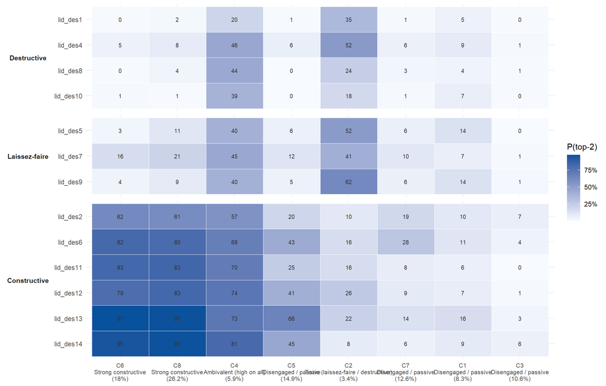

```r
ord9 <- order(-fam$Constructive, fam$Destructive)          # constructive -> toxic
lab9 <- paste0(fam$Class, "\n", fam$Label, "\n(", fam$size, "%)")[ord9]

long <- as.data.frame(top2) |>
  tibble::rownames_to_column("item") |>
  tidyr::pivot_longer(-item, names_to = "Class", values_to = "p") |>
  dplyr::mutate(type = factor(item_type[item],
                  levels = c("Destructive","Laissez-faire","Constructive")),
                item = factor(item, levels = rev(items)),
                Class = factor(Class, levels = paste0("C", 1:Kbig)[ord9],
                               labels = lab9))
ggplot(long, aes(Class, item, fill = p)) +
  geom_tile(colour = "white") +
  geom_text(aes(label = sprintf("%.0f", p*100)), size = 2.6, colour = "grey20") +
  facet_grid(type ~ ., scales = "free_y", space = "free_y", switch = "y") +
  scale_fill_gradient(low = "#F7FBFF", high = "#08519C",
                      labels = scales::percent, name = "P(top-2)") +
  labs(x = NULL, y = NULL) +
  theme_minimal(base_size = 11) +
  theme(axis.text.x = element_text(size = 8), legend.position = "right",
        strip.placement = "outside",
        strip.text.y.left = element_text(face = "bold", angle = 0))
ggsave("Figure_S_8class_itemprob.png", width = 11, height = 7, dpi = 300, bg = "white")
```

# Classification quality — AvePP and OCC

Average posterior probabilities (AvePP) and odds of correct classification (OCC) for **both** solutions. AvePP$_k$ is the mean posterior of class $k$ among its modal members (good if $>$ .70); OCC$_k = [\text{AvePP}_k/(1-\text{AvePP}_k)] \big/ [\pi_k/(1-\pi_k)]$ with $\pi_k$ the estimated prevalence (OCC $>$ 5 = good). High AvePP in the finer 8-class partition shows its extra profiles are still assigned with confidence — directly relevant to the enumeration-robustness question.

```r
class_diag <- function(post, modal) {
  K <- ncol(post); pi_k <- colMeans(post)
  AvePP <- vapply(1:K, function(k) mean(post[modal == k, k]), numeric(1))
  OCC   <- (AvePP / (1 - AvePP)) / (pi_k / (1 - pi_k))
  tibble::tibble(Class = paste0("C", 1:K),
                 `n (modal)` = as.integer(table(factor(modal, levels = 1:K))),
                 pi_k  = round(pi_k, 3),
                 AvePP = round(AvePP, 3),
                 OCC   = round(OCC, 2))
}
cd4 <- class_diag(p4, modal4)
cd9 <- class_diag(p9, modal9)
cd9$Label <- fam$Label                       # data-driven 8-class labels (C1..C8)

cd4 |> knitr::kable("markdown",
  caption = "Classification diagnostics -- 4-class (retained): AvePP and OCC.")
cd9 |> knitr::kable("markdown",
  caption = "Classification diagnostics -- 8-class: AvePP and OCC (with profile labels).")
```

Classification diagnostics – 4-class (retained): AvePP and OCC.

| Class | n (modal) | pi_k | AvePP | OCC |
| --- | --- | --- | --- | --- |
| C1 | 458 | 0.251 | 0.927 | 37.66 |
| C2 | 302 | 0.163 | 0.952 | 100.80 |
| C3 | 522 | 0.280 | 0.952 | 51.68 |
| C4 | 565 | 0.307 | 0.940 | 35.37 |

Classification diagnostics – 8-class: AvePP and OCC (with profile labels).

| Class | n (modal) | pi_k | AvePP | OCC | Label |
| --- | --- | --- | --- | --- | --- |
| C1 | 147 | 0.080 | 0.892 | 94.64 | Disengaged / passive |
| C2 | 65 | 0.038 | 0.912 | 260.57 | Toxic (laissez-faire / destructive) |
| C3 | 195 | 0.103 | 0.958 | 199.10 | Disengaged / passive |
| C4 | 105 | 0.057 | 0.905 | 159.17 | Ambivalent (high on all) |
| C5 | 291 | 0.160 | 0.837 | 27.13 | Disengaged / passive |
| C6 | 345 | 0.185 | 0.908 | 43.63 | Strong constructive |
| C7 | 236 | 0.131 | 0.895 | 56.67 | Disengaged / passive |
| C8 | 463 | 0.246 | 0.943 | 50.56 | Strong constructive |

Average posterior probabilities are high in both solutions (4-class 0.93-0.95; 8-class 0.84-0.96), all exceeding .70, with odds of correct classification above 27 throughout. Even the finer 8-class partition assigns members with high certainty, coherent with the preserved entropy.

# How do the 8 classes map onto the retained 4?

If the 8-class solution simply **refines** the 4 (each 4-class profile splitting into finer gradations) the conclusions are robust. A wholesale re-arrangement would instead signal that the 4-class structure is fragile.

```r
ct <- table(`4-class` = paste0("C", modal4), `8-class` = paste0("C", modal9))
## row-normalised: where does each 4-class profile go among the 8?
round(prop.table(ct, 1) * 100, 0) |>
  knitr::kable("markdown",
    caption = "Row % — how each retained 4-class profile distributes across the 8 classes (modal assignments).")
```

Row % — how each retained 4-class profile distributes across the 8 classes (modal assignments).

|  | C1 | C2 | C3 | C4 | C5 | C6 | C7 | C8 |
| --- | --- | --- | --- | --- | --- | --- | --- | --- |
| C1 | 0 | 0 | 0 | 10 | 16 | 72 | 2 | 0 |
| C2 | 0 | 3 | 65 | 0 | 0 | 2 | 30 | 1 |
| C3 | 0 | 1 | 0 | 1 | 8 | 2 | 0 | 88 |
| C4 | 26 | 9 | 0 | 9 | 31 | 0 | 24 | 0 |

```r
## dominant 4-class parent of each 8-class (column-wise)
parent <- apply(ct, 2, function(col) rownames(ct)[which.max(col)])
tibble::tibble(`8-class` = colnames(ct),
               `Dominant 4-class parent` = parent,
               `% in that parent` = round(apply(ct, 2, function(c) max(c)/sum(c)*100), 0)) |>
  knitr::kable("markdown", caption = "Each 8-class profile's dominant 4-class parent.")
```

Each 8-class profile’s dominant 4-class parent.

| 8-class | Dominant 4-class parent | % in that parent |
| --- | --- | --- |
| C1 | C4 | 100 |
| C2 | C4 | 78 |
| C3 | C2 | 100 |
| C4 | C4 | 50 |
| C5 | C4 | 61 |
| C6 | C1 | 95 |
| C7 | C4 | 58 |
| C8 | C3 | 99 |

# Do the covariate associations replicate?

Weighted prevalence of the key adverse exposures by 8-class profile (columns ordered constructive → toxic, as in the figure). If the gradient seen in the 4-class analysis (adverse exposures concentrated in disengaged/destructive profiles) is preserved, the substantive story is robust.

```r
covs <- c(eri="Effort-reward imbalance", bully_self="Self-labeled bullying",
          naq_frequent="Frequent negative acts (NAQ)", sex_harass="Sexual harassment",
          auditc_hazard="Hazardous alcohol (AUDIT-C)", no_union="Absence of union",
          sex_woman="Women")
wmean <- function(x, idx) { ok <- idx & !is.na(x); sum(W[ok]*x[ok]) / sum(W[ok]) }
prev <- sapply(names(covs), function(k)
  vapply(1:Kbig, function(t) wmean(d_lca[[k]], modal9 == t) * 100, numeric(1)))
rownames(prev) <- paste0("C", 1:Kbig)
prev <- prev[ord9, ]                                  # constructive -> toxic order
out <- as.data.frame(round(t(prev), 1)); colnames(out) <- fam$Class[ord9]
out <- tibble::rownames_to_column(
  `rownames<-`(out, unname(covs[rownames(out)])), "Exposure (%)")

## continuous. NB: names(x) label the output rows, values are the column keys
## passed to FUN -> use c(Label = column). (The reverse gives NaN: it would look
## up non-existent columns "Age"/"Job satisfaction" instead of age/job_sat.)
cont <- sapply(c(Age = "age", `Job satisfaction` = "job_sat"), function(k)
  vapply(1:Kbig, function(t) wmean(d_lca[[k]], modal9 == t), numeric(1)))
cont <- round(t(cont[ord9, ]), 1); colnames(cont) <- fam$Class[ord9]
out2 <- tibble::rownames_to_column(as.data.frame(cont), "Mean")
names(out2)[1] <- "Exposure (%)"

dplyr::bind_rows(out, out2) |>
  knitr::kable("markdown",
    caption = "Weighted covariate prevalence (%) and continuous means by 8-class profile (constructive -> toxic).")
```

Weighted covariate prevalence (%) and continuous means by 8-class profile (constructive -> toxic).

| Exposure (%) | C6 | C8 | C4 | C5 | C2 | C7 | C1 | C3 |
| --- | --- | --- | --- | --- | --- | --- | --- | --- |
| Effort-reward imbalance | 26.9 | 27.6 | 47.6 | 47.1 | 80.1 | 41.4 | 57.5 | 35.8 |
| Self-labeled bullying | 1.0 | 2.3 | 9.1 | 7.7 | 39.2 | 8.1 | 9.4 | 0.2 |
| Frequent negative acts (NAQ) | 1.1 | 2.8 | 21.7 | 4.9 | 30.5 | 8.7 | 11.4 | 4.9 |
| Sexual harassment | 0.0 | 1.0 | 1.6 | 1.2 | 9.3 | 1.6 | 1.5 | 0.9 |
| Hazardous alcohol (AUDIT-C) | 26.7 | 23.3 | 32.6 | 32.0 | 14.7 | 33.9 | 31.8 | 17.7 |
| Absence of union | 59.1 | 57.7 | 68.3 | 63.6 | 68.3 | 65.2 | 63.4 | 79.4 |
| Women | 35.3 | 38.4 | 37.2 | 45.1 | 64.1 | 34.8 | 37.5 | 50.5 |
| Age | 42.6 | 42.7 | 41.5 | 42.2 | 41.4 | 41.5 | 43.4 | 45.6 |
| Job satisfaction | 15.6 | 16.1 | 14.1 | 14.6 | 12.2 | 14.1 | 13.3 | 14.5 |

```r
## reference = strongest-constructive class (lowest exposure, 'healthy' baseline)
ref9 <- order(-fam$Constructive, fam$Destructive)[1]
exps <- c("eri","bully_self","naq_frequent","auditc_hazard","no_union")
or_tab <- purrr::map_dfr(exps, function(k) {
  m <- tryCatch(ml3step(d_lca[[k]], p9, modal9, sw = W, ref = ref9),
                error = function(e) NULL)
  if (is.null(m)) return(NULL)
  m$Exposure <- unname(covs[k]); m
})
ref_lab <- paste0("C", ref9)
or_tab |>
  dplyr::mutate(Profile = paste0("C", orig_class),
                lab = fam$Label[orig_class]) |>
  dplyr::transmute(Exposure, Profile = paste0(Profile, " ", lab),
                   `OR vs ref` = sprintf("%.2f (%.2f-%.2f)", OR, lo, hi)) |>
  knitr::kable("markdown",
    caption = paste0("ML three-step odds ratios, reference = ", ref_lab,
                     " (strongest constructive). OR>1 = higher exposure odds than the constructive baseline."))
```

ML three-step odds ratios, reference = C6 (strongest constructive). OR>1 = higher exposure odds than the constructive baseline.

| Exposure | Profile | OR vs ref |
| --- | --- | --- |
| Effort-reward imbalance | C1 Disengaged / passive | 4.07 (2.60-6.39) |
| Effort-reward imbalance | C2 Toxic (laissez-faire / destructive) | 15.19 (6.50-35.50) |
| Effort-reward imbalance | C3 Disengaged / passive | 1.63 (1.08-2.47) |
| Effort-reward imbalance | C4 Ambivalent (high on all) | 2.65 (1.60-4.37) |
| Effort-reward imbalance | C5 Disengaged / passive | 2.79 (1.83-4.25) |
| Effort-reward imbalance | C7 Disengaged / passive | 1.97 (1.31-2.96) |
| Effort-reward imbalance | C8 Strong constructive | 1.09 (0.76-1.55) |
| Self-labeled bullying | C1 Disengaged / passive | 24.73 (1.23-498.02) |
| Self-labeled bullying | C2 Toxic (laissez-faire / destructive) | 183.79 (9.19-3676.56) |
| Self-labeled bullying | C3 Disengaged / passive | 0.02 (0.00-19447083433720.41) |
| Self-labeled bullying | C4 Ambivalent (high on all) | 24.11 (1.11-521.56) |
| Self-labeled bullying | C5 Disengaged / passive | 21.74 (0.99-477.08) |
| Self-labeled bullying | C7 Disengaged / passive | 20.39 (1.01-410.89) |
| Self-labeled bullying | C8 Strong constructive | 5.32 (0.25-112.58) |
| Frequent negative acts (NAQ) | C1 Disengaged / passive | 21.66 (2.37-198.25) |
| Frequent negative acts (NAQ) | C2 Toxic (laissez-faire / destructive) | 82.36 (8.91-761.73) |
| Frequent negative acts (NAQ) | C3 Disengaged / passive | 8.46 (0.88-81.46) |
| Frequent negative acts (NAQ) | C4 Ambivalent (high on all) | 50.08 (5.34-469.29) |
| Frequent negative acts (NAQ) | C5 Disengaged / passive | 7.69 (0.70-83.90) |
| Frequent negative acts (NAQ) | C7 Disengaged / passive | 15.70 (1.70-144.76) |
| Frequent negative acts (NAQ) | C8 Strong constructive | 4.63 (0.48-44.36) |
| Hazardous alcohol (AUDIT-C) | C1 Disengaged / passive | 1.31 (0.83-2.08) |
| Hazardous alcohol (AUDIT-C) | C2 Toxic (laissez-faire / destructive) | 0.42 (0.17-1.02) |
| Hazardous alcohol (AUDIT-C) | C3 Disengaged / passive | 0.57 (0.35-0.93) |
| Hazardous alcohol (AUDIT-C) | C4 Ambivalent (high on all) | 1.38 (0.83-2.32) |
| Hazardous alcohol (AUDIT-C) | C5 Disengaged / passive | 1.34 (0.87-2.07) |
| Hazardous alcohol (AUDIT-C) | C7 Disengaged / passive | 1.49 (1.00-2.24) |
| Hazardous alcohol (AUDIT-C) | C8 Strong constructive | 0.84 (0.58-1.20) |
| Absence of union | C1 Disengaged / passive | 1.20 (0.78-1.86) |
| Absence of union | C2 Toxic (laissez-faire / destructive) | 1.55 (0.82-2.94) |
| Absence of union | C3 Disengaged / passive | 2.83 (1.82-4.41) |
| Absence of union | C4 Ambivalent (high on all) | 1.55 (0.93-2.59) |
| Absence of union | C5 Disengaged / passive | 1.25 (0.83-1.87) |
| Absence of union | C7 Disengaged / passive | 1.31 (0.89-1.93) |
| Absence of union | C8 Strong constructive | 0.95 (0.70-1.30) |

ML three-step odds ratios (95% CI) for each adverse exposure: odds of membership in each 8-class profile vs the strongest-constructive reference. CIs widen for the smallest (toxic) class — read directionally.

# The 5-class solution (AWE minimum)

The 8-class model above is the **global BIC minimum** on the 13 items. Parsimony-oriented criteria point lower: in the enumeration the **AWE (approximate weight of evidence) — the most strongly parsimony-penalising information criterion reported there — is minimised at 5 classes**, while CAIC favours 7 and BIC 8. Reporting the **5-class** solution therefore brackets the enumeration uncertainty from the *parsimonious* side, complementing the BIC-preferred 8-class from the *rich* side; between them they span the plausible model-size range a reviewer would ask about.

We re-estimate the identical measurement model with `nclass = 5` (same 13 items with item 3 excluded, same `~ sex_woman` concomitant, same lucky seed 2125 and `n.init`), reusing the notebook’s own `fit_glca()`, `get_rho()`, `wsize()`, `item_type`, `label_class()` and `class_diag()` helpers so the 5-class is characterised on **exactly the same thresholds** as the 8-class. The folded `helpers-5class` chunk (above) fits `g5` and builds `fam5`/`ord5`/`ref5`/`cd5` **once**; the 5-class figure and covariate/ML three-step tables below consume those objects unchanged. The 8-class outputs are left intact.

The fit line below sits alongside the 4- vs 8-class comparison; `fam5` gives the weighted size, family mean scores and data-driven label of each profile (ordered constructive → toxic); `cd5` gives the AvePP/OCC classification diagnostics.

```r
## ============================================================================
## SHARED 5-CLASS MACHINERY -- defined ONCE, consumed by fit-5class, fig-5class,
## table2-5class, s1-5class, s2-5class below. PASTE this chunk immediately AFTER
## the existing `ml3step-or` chunk (i.e. under the new "# The 5-class solution
## (AWE minimum)" heading, right after the AWE motivation paragraph). By this
## point EVERY reused helper already exists and NOTHING above is modified:
##   fit_glca/item_f/wsize/W       (chunk `fits`)
##   get_post/get_rho/class_matrix/relative_entropy  (chunk `helpers`)
##   item_type/label_class         (chunk `profile-scores`)
##   class_diag                    (chunk `avepp-occ`)
##   covs/wmean                    (chunk `covariate-prev`)
## Every NEW name (g5/p5/modal5/rho5/top2_5/fam5/ord5/ref5/cd5/K5/fam_mean5/
## item_label/ml3step_fit/ml3step_margins) is distinct from the 8-class objects
## (g9/p9/modal9/rho9/top2/fam/ord9/cd9/Kbig/fam_mean), so the 8-class outputs
## stay byte-for-byte intact. This chunk prints nothing (pure setup).
## ----------------------------------------------------------------------------

## (1) English item labels for the full four-category figure (ported verbatim
##     from the MAIN analysis `item_meta`), a NAMED vector aligned to `items`.
item_label <- c(
  lid_des1  = "Humiliates employees",
  lid_des2  = "Encourages creative ideas",
  lid_des4  = "Gestures of displeasure",
  lid_des5  = "Avoids making decisions",
  lid_des6  = "Recognizes good performance",
  lid_des7  = "Avoids involvement in work",
  lid_des8  = "Spreads false information",
  lid_des9  = "Absent when needed",
  lid_des10 = "Berates by phone / rude email",
  lid_des11 = "Seeks to develop capabilities",
  lid_des12 = "Sets clear objectives",
  lid_des13 = "Defines / explains tasks",
  lid_des14 = "Flexible, open to innovation")
stopifnot(identical(names(item_label), items))     # guard alignment to `items`

## (2) ml3step_fit(): IDENTICAL estimator to ml3step() (same negll, same `ref`
##     reorder to the logit baseline), but ALSO returns par/V/K/ord so a SINGLE
##     fit feeds BOTH the odds ratios (Table S1) and the marginal predicted
##     probabilities (Table S2). ml3step() itself is left untouched, so the
##     8-class `ml3step-or` chunk (which expects the bare tibble) still runs.
ml3step_fit <- function(z, post, modal, sw = NULL, ref = 1L, D = NULL) {
  post <- as.matrix(post); K <- ncol(post)
  if (is.null(sw)) sw <- rep(1, nrow(post))
  if (is.null(D)) D <- class_matrix(post, modal)     # fixed D on FULL sample
  ord <- c(ref, setdiff(seq_len(K), ref))            # ref -> baseline (reordered class 1)
  D <- D[ord, ord]; modal <- match(modal, ord)
  z <- as.numeric(z); ok <- !is.na(z)
  z <- z[ok]; modal <- modal[ok]; sw <- sw[ok]; n <- length(z)
  Dw <- t(D[, modal])
  negll <- function(par) {
    a <- c(0, par[seq(1, 2*(K-1), 2)]); b <- c(0, par[seq(2, 2*(K-1), 2)])
    eta <- outer(rep(1, n), a) + outer(z, b); eta <- eta - apply(eta, 1, max)
    pis <- exp(eta); pis <- pis / rowSums(pis)
    -sum(sw * log(pmax(rowSums(pis * Dw), 1e-12)))
  }
  fit <- optim(rep(0, 2*(K-1)), negll, method = "BFGS", hessian = TRUE)
  V <- tryCatch(solve(fit$hessian),
                error = function(e) matrix(NA, length(fit$par), length(fit$par)))
  bi <- seq(2, 2*(K-1), 2); b <- fit$par[bi]; se <- sqrt(diag(V))[bi]
  ors <- tibble::tibble(class_ord = 2:K, orig_class = ord[-1],
                        OR = exp(b), lo = exp(b - 1.96*se), hi = exp(b + 1.96*se))
  list(par = fit$par, V = V, K = K, ord = ord, ors = ors, conv = fit$convergence)
}

## (3) ml3step_margins(): parametric-bootstrap marginal predicted probabilities
##     P(X=t | z) at z=0 and z=1 with 95% CIs + the difference (ported from MAIN).
##     MASS is NOT attached here -> call via MASS:: (never masks dplyr::select;
##     MASS is a recommended package, always installed). REORDER-AWARE: column j
##     of z0/z1/delta is REORDERED class j = ORIGINAL class m$ord[j] (column 1 =
##     the reference). The CALLER maps a wanted original class to its column with
##     match(orig, m$ord).
ml3step_margins <- function(m, B = 2000) {
  K <- m$K; par <- m$par; V <- m$V
  draws <- MASS::mvrnorm(B, mu = par, Sigma = V)
  probs <- function(p, z) {
    a <- c(0, p[seq(1, 2*(K-1), 2)]); b <- c(0, p[seq(2, 2*(K-1), 2)])
    eta <- a + z * b; e <- exp(eta - max(eta)); e / sum(e)
  }
  p0 <- t(apply(draws, 1, probs, z = 0))            # B x K
  p1 <- t(apply(draws, 1, probs, z = 1))
  q  <- function(M) apply(M, 2, quantile, c(.025, .5, .975))
  list(z0 = q(p0), z1 = q(p1),
       delta = apply(p1 - p0, 2, quantile, c(.025, .5, .975)))
}

## (4) Fit the 5-class model (AWE minimum). Same fitter/seed/n.init as g4/g9:
##     fit_glca() runs in the main process (Mersenne-Twister) with the 2125->2134
##     fallback, so it is exactly reproducible and no furrr/L'Ecuyer issue arises.
K5 <- 5
g5 <- fit_glca(K5)
p5 <- get_post(g5); modal5 <- max.col(p5)
stopifnot(length(modal5) == nrow(d_lca))

## (5) Data-driven family scores + labels for the 5 profiles, built EXACTLY as the
##     8-class `fam` (rho -> top-2 category prob -> per-type mean -> label_class).
##     top2_5 rows kept aligned to `items` (13 rows) via item_type[rownames].
rho5   <- get_rho(g5)
top2_5 <- t(vapply(seq_along(items),
                   function(j) rho5[[j]][, 3] + rho5[[j]][, 4], numeric(K5)))
rownames(top2_5) <- items; colnames(top2_5) <- paste0("C", 1:K5)

fam_mean5 <- function(type) colMeans(top2_5[item_type[rownames(top2_5)] == type, , drop = FALSE])
fam5 <- tibble::tibble(
  Class           = paste0("C", 1:K5),
  size            = round(wsize(modal5, K5), 1),
  Constructive    = round(fam_mean5("Constructive"), 2),
  `Laissez-faire` = round(fam_mean5("Laissez-faire"), 2),
  Destructive     = round(fam_mean5("Destructive"), 2))
## SAME data-driven labeller as the 8-class (no hand-coded class numbers).
fam5$Label <- mapply(label_class, fam5$Constructive, fam5$`Laissez-faire`, fam5$Destructive)

## constructive -> toxic DISPLAY order + strongest-constructive reference. fam5
## rows stay in ORIGINAL glca order (C1..C5); ord5 permutes only the DISPLAY, so
## labels can never be mis-assigned (identical discipline to ord9/ref9).
ord5     <- order(-fam5$Constructive, fam5$Destructive)
ref5     <- ord5[1]
ref_lab5 <- paste0("C", ref5)

## (6) Classification diagnostics via the SAME class_diag() used for 4-/8-class.
##     cd5 and fam5 are both in natural C1..C5 order, so the Label column aligns
##     row-for-row (exactly as cd9$Label <- fam$Label for the 8-class).
cd5 <- class_diag(p5, modal5)
cd5$Label <- fam5$Label
```

```r
## Compact fit line (compare with the 4- vs 8-class table above); reuses the same
## gof slots and relative_entropy()/wsize() helpers.
tibble::tibble(
  Solution = "5-class (AWE minimum)",
  logLik   = g5$gof$loglik,
  AIC      = g5$gof$aic,
  BIC      = g5$gof$bic,
  Entropy  = relative_entropy(p5),
  `Smallest class %` = min(wsize(modal5, K5))
) |>
  dplyr::mutate(dplyr::across(where(is.numeric), ~round(.x, 3))) |>
  knitr::kable("markdown", caption = "5-class fit summary (AWE minimum).")

## Profiles: weighted size, family scores (mean P of the top-2 categories) and
## the data-driven label, ordered constructive -> toxic (ord5).
fam5[ord5, ] |> knitr::kable("markdown",
  caption = "5-class profiles (AWE minimum): weighted size, family scores (mean P of top-2 categories) and data-driven label, ordered constructive -> toxic.")

## Classification quality (AvePP > .70 good; OCC > 5 good), natural C1..C5 order
## with the aligned data-driven labels.
cd5 |> knitr::kable("markdown",
  caption = "Classification diagnostics -- 5-class (AWE minimum): AvePP and OCC (with profile labels).")
```

5-class fit summary (AWE minimum).

| Solution | logLik | Entropy | Smallest class % |
| --- | --- | --- | --- |
| 5-class (AWE minimum) | -20901.22 | 0.896 | 8.682 |

5-class profiles (AWE minimum): weighted size, family scores (mean P of top-2 categories) and data-driven label, ordered constructive -> toxic.

| Class | size | Constructive | Laissez-faire | Destructive | Label |
| --- | --- | --- | --- | --- | --- |
| C2 | 29.0 | 0.81 | 0.13 | 0.04 | Strong constructive |
| C5 | 23.1 | 0.78 | 0.08 | 0.02 | Strong constructive |
| C1 | 8.7 | 0.46 | 0.50 | 0.40 | Constructive (moderate) |
| C4 | 24.2 | 0.16 | 0.08 | 0.03 | Disengaged / passive |
| C3 | 15.0 | 0.07 | 0.03 | 0.02 | Disengaged / passive |

Classification diagnostics – 5-class (AWE minimum): AvePP and OCC (with profile labels).

| Class | n (modal) | pi_k | AvePP | OCC | Label |
| --- | --- | --- | --- | --- | --- |
| C1 | 155 | 0.085 | 0.902 | 99.44 | Constructive (moderate) |
| C2 | 511 | 0.270 | 0.942 | 43.78 | Strong constructive |
| C3 | 275 | 0.151 | 0.969 | 173.34 | Disengaged / passive |
| C4 | 464 | 0.252 | 0.924 | 36.05 | Disengaged / passive |
| C5 | 442 | 0.242 | 0.922 | 37.17 | Strong constructive |

## What do the 5 profiles look like? (full item-response probabilities)

The 8-class figure above summarises each item by its top-two-category probability (a heatmap), which is compact but hides the shape of the response distribution. For the **5-class** solution we instead reproduce the **full four-category stacked-bar style of Figure 2 of the main analysis** (`Figure2_itemprob.png`). Each horizontal bar decomposes an item’s response distribution into *Never / Sometimes / Fairly often / Almost always/always* for one profile, so the 5-class measurement structure can be read — and compared against the retained 4-class Figure 2 — at full resolution. Rows are the 13 items grouped by behaviour **type**; columns are the 5 profiles ordered from most **constructive** to most **toxic** (same `fam5`/`ord5`/`label_class` machinery as the 8-class figure, adapted to K = 5), each headed by its data-driven label and weighted size.

Figure 2: Full four-category item-response probabilities for the 5-class solution (the AWE minimum in the 13-item enumeration). Horizontal stacked bars give P(response category) for each item; rows = items grouped by behaviour type; columns = profiles ordered from most constructive to most toxic. Same style as Figure 2 of the main analysis, so the 5-class measurement structure can be compared with the retained 4-class Figure 2.

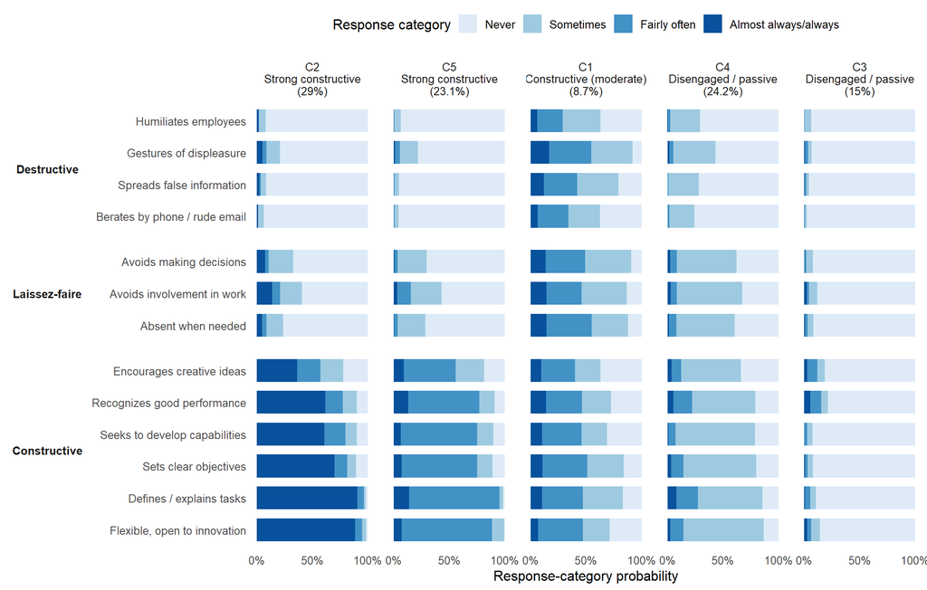

```r
## Same visual grammar as MAIN Figure 2 (Figure2_itemprob.png): ALL FOUR response
## categories stacked per item x class -- NOT the top-2 heatmap used for the
## 8-class figure above. rho5[[j]] (from helpers-5class) is 5 x 4 (rows = class,
## cols = category). Columns are ordered/labelled with the SAME fam5/ord5 machinery
## as fig-9class.
cats <- c("Never", "Sometimes", "Fairly often", "Almost always/always")
blue <- c("#DEEBF7", "#9ECAE1", "#4292C6", "#08519C")

## multi-line column headers (class + data-driven label + weighted size),
## reordered constructive -> toxic (mirrors lab9 in fig-9class).
lab5 <- paste0(fam5$Class, "\n", fam5$Label, "\n(", fam5$size, "%)")[ord5]

rho_long <- purrr::map_dfr(seq_along(items), function(j) {
  m <- rho5[[j]]                                      # 5 x 4
  tidyr::expand_grid(class = 1:K5, cat = 1:4) |>
    dplyr::mutate(p    = as.vector(t(m))[(class - 1) * 4 + cat],
                  item = items[j])
}) |>
  dplyr::mutate(
    type  = factor(item_type[item],
                   levels = c("Destructive", "Laissez-faire", "Constructive")),
    label = factor(item_label[item], levels = rev(item_label)),
    cat   = factor(cats[cat], levels = cats),
    ## levels AND labels both permuted by ord5 -> column order (constructive ->
    ## toxic) and its printed label stay locked together (no label switching).
    class = factor(paste0("C", class),
                   levels = paste0("C", 1:K5)[ord5], labels = lab5))

fig5 <- ggplot(rho_long, aes(p, label, fill = cat)) +
  geom_col(width = .72) +
  facet_grid(type ~ class, scales = "free_y", space = "free_y", switch = "y") +
  scale_fill_manual(values = blue, name = "Response category") +
  scale_x_continuous(labels = scales::percent_format(accuracy = 1),
                     breaks = c(0, .5, 1), expand = expansion(mult = .04)) +
  labs(x = "Response-category probability", y = NULL) +
  theme_minimal(base_size = 12) +
  theme(legend.position = "top", panel.spacing.x = unit(1, "lines"),
        panel.grid = element_blank(), strip.placement = "outside",
        strip.text.y.left = element_text(face = "bold", angle = 0))
fig5
ggsave("Figure_S_5class_itemprob.png", fig5, width = 11, height = 7, dpi = 300, bg = "white")
```

## Table 2 analog for the 5-class (AWE-minimum) solution

The table below is the sensitivity-notebook counterpart of the main file’s **Table 2** (survey-weighted profile characteristics), rebuilt for these 5 modal profiles. Consistent with the rest of this notebook it uses the **reduced covariate set** already cleaned here (`covs`: effort-reward imbalance, self-labeled bullying, frequent NAQ acts, sexual harassment, hazardous alcohol, absence of union, women; plus continuous age and job satisfaction) with the **simple survey weights** `W` and `wmean()` — weighted % for the binary exposures and weighted means for the continuous ones. This is intentionally the lightweight weights-only design used throughout the sensitivity file, **not** the main file’s full `svydesign` / median (Q1–Q3) Table 2. Columns are ordered constructive → toxic (`ord5`) with the data-driven `fam5` labels, so the adverse-exposure gradient can be read left-to-right and compared with the 8-class table above.

```r
## Table 2 analog for the 5-class (AWE-minimum) solution: weighted covariate
## characteristics by MODAL profile, columns ordered constructive -> toxic with
## the fam5 labels. Reuses this notebook's reduced covariate set (`covs`), the
## simple weights W and wmean() from the 8-class `covariate-prev` chunk --
## deliberately the same lightweight design as the rest of this sensitivity
## notebook, NOT the main file's full svydesign / median Table 2.

## SINGLE-LINE headers for markdown (a "\n" would break kable): class + label +
## weighted size, reordered constructive -> toxic. (Named hd5 to avoid reusing
## the multi-line `lab5` built in fig-5class.)
hd5 <- paste0(fam5$Class, " ", fam5$Label, " (", fam5$size, "%)")[ord5]

## binaries -> weighted %
prev5 <- sapply(names(covs), function(k)
  vapply(1:K5, function(t) wmean(d_lca[[k]], modal5 == t) * 100, numeric(1)))
rownames(prev5) <- paste0("C", 1:K5)
prev5 <- prev5[ord5, ]                                       # constructive -> toxic
## assign the (non-syntactic) headers AFTER as.data.frame so both sub-tables carry
## identical column-name strings and bind_rows() aligns them cleanly.
out5 <- as.data.frame(round(t(prev5), 1)); colnames(out5) <- hd5
out5 <- tibble::rownames_to_column(
  `rownames<-`(out5, unname(covs[rownames(out5)])), "Characteristic")

## continuous -> weighted mean (covariate-prev style). NB: names() are the display
## labels; the values are the column keys passed to wmean().
cont5 <- sapply(c(`Age, mean (years)`      = "age",
                  `Job satisfaction, mean` = "job_sat"), function(k)
  vapply(1:K5, function(t) wmean(d_lca[[k]], modal5 == t), numeric(1)))
cont5 <- round(t(cont5[ord5, ]), 1)
out5b <- as.data.frame(cont5); colnames(out5b) <- hd5
out5b <- tibble::rownames_to_column(out5b, "Characteristic")

dplyr::bind_rows(out5, out5b) |>
  knitr::kable("markdown",
    caption = paste0("Table 2 (5-class analog). Weighted covariate characteristics by ",
                     "modal leadership profile (binaries: weighted %; continuous: weighted ",
                     "mean), ordered constructive -> toxic. Notebook reduced covariate set ",
                     "+ simple weights (cf. main-file survey-design Table 2)."))
```

Table 2 (5-class analog). Weighted covariate characteristics by modal leadership profile (binaries: weighted %; continuous: weighted mean), ordered constructive -> toxic. Notebook reduced covariate set + simple weights (cf. main-file survey-design Table 2).

| Characteristic | C2 Strong constructive (29%) | C5 Strong constructive (23.1%) | C1 Constructive (moderate) (8.7%) | C4 Disengaged / passive (24.2%) | C3 Disengaged / passive (15%) |
| --- | --- | --- | --- | --- | --- |
| Effort-reward imbalance | 28.8 | 30.4 | 63.3 | 49.8 | 36.9 |
| Self-labeled bullying | 2.3 | 3.2 | 21.9 | 7.9 | 2.6 |
| Frequent negative acts (NAQ) | 3.1 | 3.1 | 26.4 | 7.4 | 5.7 |
| Sexual harassment | 1.0 | 0.1 | 6.3 | 1.3 | 0.8 |
| Hazardous alcohol (AUDIT-C) | 22.8 | 30.0 | 24.8 | 32.2 | 22.9 |
| Absence of union | 58.6 | 61.4 | 69.4 | 61.9 | 75.8 |
| Women | 39.3 | 38.1 | 42.5 | 39.6 | 46.1 |
| Age, mean (years) | 42.4 | 42.7 | 41.0 | 42.5 | 44.7 |
| Job satisfaction, mean | 16.0 | 15.4 | 13.3 | 13.9 | 14.5 |

## Table S1 analog (5-class) — ML three-step odds ratios

Odds of membership in each 5-class profile **versus the strongest-constructive reference** (`ref5 = ord5[1]`), one covariate at a time, from `ml3step_fit()` — the same estimator as `ml3step()`, only additionally returning `par/V/K/ord` so the **same fits also feed Table S2** below. The full 7-covariate set is used (as in the main file’s Table S1). OR > 1 = higher exposure odds than the healthiest profile; CIs widen for the smallest profiles, so read directionally.

```r
## Reference = strongest-constructive class (ord5[1]); one covariate at a time.
## ml3step_fit() returns BOTH $ors AND par/V/K/ord, so the SAME fitted models feed
## Table S2 (margins) below -- fit once, use twice. Full 7-covariate set (as MAIN).
exps5 <- c("eri", "bully_self", "naq_frequent", "auditc_hazard", "no_union",
           "sex_harass", "sex_woman")
ml_models5 <- lapply(exps5, function(k)
  tryCatch(ml3step_fit(d_lca[[k]], p5, modal5, sw = W, ref = ref5),
           error = function(e) NULL))
names(ml_models5) <- exps5

## $ors$orig_class is the ORIGINAL class index -> fam5 labels align directly.
## Display constructive -> toxic via a Profile factor ordered by ord5 (the
## reference ord5[1] never appears among the non-baseline OR rows).
prof_lev5 <- paste0("C", ord5, " ", fam5$Label[ord5])
or_tab5 <- purrr::imap_dfr(ml_models5, function(m, k) {
  if (is.null(m)) return(NULL)
  dplyr::mutate(m$ors,
                Exposure = unname(covs[k]),
                Profile  = paste0("C", orig_class, " ", fam5$Label[orig_class]))
})
or_tab5 |>
  dplyr::mutate(Exposure = factor(Exposure, levels = unname(covs[exps5])),
                Profile  = factor(Profile,  levels = prof_lev5)) |>
  dplyr::arrange(Exposure, Profile) |>
  dplyr::transmute(Exposure, Profile,
                   `OR vs ref (95% CI)` = sprintf("%.2f (%.2f-%.2f)", OR, lo, hi)) |>
  knitr::kable("markdown",
    caption = paste0("Table S1 analog (5-class): ML three-step odds ratios, reference = ",
                     ref_lab5, " ", fam5$Label[ref5],
                     " (strongest constructive). OR>1 = higher exposure odds than the constructive baseline."))
```

Table S1 analog (5-class): ML three-step odds ratios, reference = C2 Strong constructive (strongest constructive). OR>1 = higher exposure odds than the constructive baseline.

| Exposure | Profile | OR vs ref (95% CI) |
| --- | --- | --- |
| Effort-reward imbalance | C5 Strong constructive | 1.04 (0.76-1.43) |
| Effort-reward imbalance | C1 Constructive (moderate) | 4.74 (3.13-7.18) |
| Effort-reward imbalance | C4 Disengaged / passive | 2.57 (1.93-3.42) |
| Effort-reward imbalance | C3 Disengaged / passive | 1.46 (1.06-2.01) |
| Self-labeled bullying | C5 Strong constructive | 1.32 (0.51-3.42) |
| Self-labeled bullying | C1 Constructive (moderate) | 13.99 (6.52-30.01) |
| Self-labeled bullying | C4 Disengaged / passive | 3.89 (1.84-8.24) |
| Self-labeled bullying | C3 Disengaged / passive | 1.14 (0.40-3.19) |
| Frequent negative acts (NAQ) | C5 Strong constructive | 0.89 (0.36-2.22) |
| Frequent negative acts (NAQ) | C1 Constructive (moderate) | 13.06 (6.73-25.38) |
| Frequent negative acts (NAQ) | C4 Disengaged / passive | 2.51 (1.27-4.95) |
| Frequent negative acts (NAQ) | C3 Disengaged / passive | 1.96 (0.92-4.18) |
| Hazardous alcohol (AUDIT-C) | C5 Strong constructive | 1.50 (1.09-2.07) |
| Hazardous alcohol (AUDIT-C) | C1 Constructive (moderate) | 1.10 (0.70-1.75) |
| Hazardous alcohol (AUDIT-C) | C4 Disengaged / passive | 1.68 (1.24-2.29) |
| Hazardous alcohol (AUDIT-C) | C3 Disengaged / passive | 1.01 (0.70-1.45) |
| Absence of union | C5 Strong constructive | 1.13 (0.85-1.51) |
| Absence of union | C1 Constructive (moderate) | 1.68 (1.11-2.56) |
| Absence of union | C4 Disengaged / passive | 1.14 (0.86-1.50) |
| Absence of union | C3 Disengaged / passive | 2.29 (1.63-3.22) |
| Sexual harassment | C5 Strong constructive | 0.00 (0.00-85386525108.87) |
| Sexual harassment | C1 Constructive (moderate) | 7.51 (2.43-23.15) |
| Sexual harassment | C4 Disengaged / passive | 1.19 (0.31-4.56) |
| Sexual harassment | C3 Disengaged / passive | 0.83 (0.16-4.26) |
| Women | C5 Strong constructive | 0.94 (0.71-1.26) |
| Women | C1 Constructive (moderate) | 1.15 (0.78-1.71) |
| Women | C4 Disengaged / passive | 1.01 (0.76-1.33) |
| Women | C3 Disengaged / passive | 1.34 (0.98-1.81) |

## Table S2 analog (5-class) — marginal predicted probabilities

Predicted P(profile | covariate) at *No* (z = 0) and *Yes* (z = 1) with parametric-bootstrap 95% CIs and the difference Δ (pp), from the **same** `ml_models5` fits used for Table S1. Because `ml3step_fit()` reorders classes so the reference is the logit baseline, each margins column is remapped to its `fam5` label via `match(orig_class, m$ord)` before display (constructive → toxic). The lucky seed 2125 fixes the `MASS::mvrnorm` draws so the CIs are reproducible.

```r
## Marginal predicted probabilities P(profile | z) at z=0 (No) vs z=1 (Yes), with
## parametric-bootstrap 95% CIs and the difference (pp), from the SAME ml_models5
## fits. Lucky seed 2125 for the mvrnorm draws -> reproducible CIs.
set.seed(2125)
## fam5 labels are indexed by ORIGINAL class; margins columns are REORDERED, so map
## each displayed class back to its column with match(orig_class, m$ord).
mg_lab5 <- paste0(fam5$Class, " ", fam5$Label)
s2_5 <- purrr::imap_dfr(ml_models5, function(m, k) {
  if (is.null(m)) return(NULL)
  mg <- ml3step_margins(m)                    # cols j of z0/z1/delta -> orig class m$ord[j]
  purrr::map_dfr(seq_along(ord5), function(pos) {
    c_orig <- ord5[pos]                       # original class to show (constructive -> toxic)
    j      <- match(c_orig, m$ord)            # its column in the margins matrices
    tibble::tibble(
      Covariate = ifelse(pos == 1, unname(covs[k]), ""),
      Profile   = mg_lab5[c_orig],
      `No (z=0), % (95% CI)`  = sprintf("%.1f (%.1f-%.1f)", 100*mg$z0[2, j], 100*mg$z0[1, j], 100*mg$z0[3, j]),
      `Yes (z=1), % (95% CI)` = sprintf("%.1f (%.1f-%.1f)", 100*mg$z1[2, j], 100*mg$z1[1, j], 100*mg$z1[3, j]),
      `Delta (pp)`            = sprintf("%+.1f", 100*mg$delta[2, j]))
  })
})
s2_5 |> knitr::kable("markdown",
  caption = paste0("Table S2 analog (5-class): marginal predicted probabilities at z=0 (No) vs z=1 (Yes), ",
                   "with the difference (pp). Profiles ordered constructive -> toxic; logit baseline = ",
                   ref_lab5, "."))
```

Table S2 analog (5-class): marginal predicted probabilities at z=0 (No) vs z=1 (Yes), with the difference (pp). Profiles ordered constructive -> toxic; logit baseline = C2.

| Covariate | Profile | No (z=0), % (95% CI) | Yes (z=1), % (95% CI) | Delta (pp) |
| --- | --- | --- | --- | --- |
| Effort-reward imbalance | C2 Strong constructive | 32.9 (30.1-36.0) | 21.0 (17.8-24.2) | -12.0 |
|  | C5 Strong constructive | 26.7 (24.0-29.7) | 17.7 (14.7-21.0) | -9.0 |
|  | C1 Constructive (moderate) | 5.0 (3.7-6.6) | 14.9 (12.2-18.2) | +9.9 |
|  | C4 Disengaged / passive | 19.4 (16.8-22.1) | 31.7 (28.0-35.7) | +12.3 |
|  | C3 Disengaged / passive | 15.7 (13.6-18.0) | 14.5 (12.0-17.4) | -1.2 |
| Self-labeled bullying | C2 Strong constructive | 29.4 (27.2-31.7) | 10.6 (5.7-19.5) | -18.7 |
|  | C5 Strong constructive | 24.0 (21.9-26.5) | 11.5 (6.1-21.0) | -12.6 |
|  | C1 Constructive (moderate) | 7.1 (5.8-8.6) | 36.0 (26.1-46.9) | +29.0 |
|  | C4 Disengaged / passive | 23.5 (21.4-25.8) | 33.2 (23.9-44.8) | +9.7 |
|  | C3 Disengaged / passive | 15.8 (14.0-17.8) | 6.6 (2.9-14.0) | -9.1 |
| Frequent negative acts (NAQ) | C2 Strong constructive | 29.5 (27.3-31.7) | 12.6 (7.4-20.7) | -16.8 |
|  | C5 Strong constructive | 24.3 (22.0-26.5) | 9.2 (4.7-17.5) | -14.9 |
|  | C1 Constructive (moderate) | 6.8 (5.5-8.2) | 37.8 (28.4-47.8) | +30.9 |
|  | C4 Disengaged / passive | 24.0 (21.9-26.2) | 25.8 (18.2-35.3) | +1.8 |
|  | C3 Disengaged / passive | 15.4 (13.8-17.2) | 13.0 (7.8-20.9) | -2.4 |
| Hazardous alcohol (AUDIT-C) | C2 Strong constructive | 30.2 (27.7-32.8) | 23.5 (19.9-27.6) | -6.7 |
|  | C5 Strong constructive | 22.2 (19.8-24.8) | 26.2 (22.3-30.7) | +4.0 |
|  | C1 Constructive (moderate) | 9.1 (7.6-10.8) | 8.0 (5.6-11.0) | -1.1 |
|  | C4 Disengaged / passive | 22.2 (19.9-24.8) | 29.2 (25.0-33.7) | +6.9 |
|  | C3 Disengaged / passive | 16.2 (14.2-18.3) | 12.8 (10.0-16.1) | -3.3 |
| Absence of union | C2 Strong constructive | 32.5 (28.5-36.2) | 26.0 (23.6-28.7) | -6.4 |
|  | C5 Strong constructive | 24.7 (21.4-28.5) | 22.4 (19.8-25.1) | -2.3 |
|  | C1 Constructive (moderate) | 7.2 (5.2-9.8) | 9.7 (8.1-11.8) | +2.5 |
|  | C4 Disengaged / passive | 25.5 (22.1-29.3) | 23.3 (20.7-25.9) | -2.1 |
|  | C3 Disengaged / passive | 9.9 (7.8-12.6) | 18.3 (16.2-20.8) | +8.4 |
| Sexual harassment | C2 Strong constructive | 28.6 (26.6-30.8) | 14.6 (0.0-39.9) | -13.9 |
|  | C5 Strong constructive | 23.6 (21.4-25.8) | 0.1 (0.0-100.0) | -22.1 |
|  | C1 Constructive (moderate) | 8.3 (6.9-9.8) | 36.2 (0.0-63.5) | +27.9 |
|  | C4 Disengaged / passive | 24.1 (22.0-26.3) | 14.6 (0.0-41.9) | -9.6 |
|  | C3 Disengaged / passive | 15.3 (13.7-17.1) | 5.6 (0.0-25.5) | -9.7 |
| Women | C2 Strong constructive | 28.9 (26.2-31.9) | 27.6 (24.4-31.1) | -1.3 |
|  | C5 Strong constructive | 24.2 (21.4-27.2) | 21.8 (18.5-25.3) | -2.4 |
|  | C1 Constructive (moderate) | 8.5 (6.8-10.6) | 9.3 (7.3-11.9) | +0.8 |
|  | C4 Disengaged / passive | 24.5 (21.8-27.5) | 23.5 (20.4-27.2) | -1.0 |
|  | C3 Disengaged / passive | 13.7 (11.8-15.9) | 17.5 (14.8-20.6) | +3.8 |

# Verdict — is the 8-class a reasonable sensitivity analysis?

- Entropy stays high (8-class = 0.884 vs 4-class = 0.896): clean separation is preserved.
- Smallest 8-class profile = 3.4% (n = 65): small but estimable.
- Adjusted Rand index (4 vs 8 modal partitions) = 0.53 (0 = unrelated, 1 = identical): the 8-class partition **moderately overlaps** the 4 — consistent with the 8 classes being *splits/refinements* of the 4 (see the cross-tab), not an unrelated re-arrangement.

**Reasonable? Yes — and well-motivated**, because the information criteria favour a much larger solution than 4 (BIC is minimised at 8, CAIC at 7), so reporting the 8-class model pre-empts the obvious reviewer question about why 4 was retained. The 8-class solution **refines** the 4 (the constructive profile reappears as two near-duplicate classes; a four-way disengaged/passive gradient; the ambivalent profile persists) rather than overturning them, entropy is preserved, and the **covariate gradient replicates** — evidence that the 4-class substantive conclusions are robust to enumeration uncertainty.

**Two honest caveats.** (1) Much of the extra structure is *redundant* (near-duplicate constructive classes; several flavours of disengagement that differ by degree, not kind), which is why 4 remains the more parsimonious, communicable choice for the main model — and why the BIC gain of the 8-class over the adjacent 7-class is marginal (~20 points). (2) This tests sensitivity to **enumeration**, a different axis from the **classification-error** (naive-vs-BCH) sensitivity in the main file’s Table S3 — report both; they answer different questions. The one genuinely new substantive signal is a small **toxic** profile (3.4%, n = 65) that the 4-class model does not isolate — it is absorbed into a broader 4-class profile (~78%) — and that concentrates the adverse exposures (the highest prevalence of effort-reward imbalance, self-labeled bullying, frequent negative acts and sexual harassment of any profile).